# [26기] 4팀 문서영 3주차 패키지 과제

문서영

2021 3 23

# Chapter 1. 모델링을 위한 전처리

### 문제 0. 기본세팅

```r
library(tidyverse)
library(data.table)
library(gridExtra)
library(magrittr)
setwd('C:/Users/paa04/OneDrive/바탕 화면/P-SAT/21-1/데마/클린업/3주차패키지')
data <- fread("data.csv",
              header = T,
              stringsAsFactors = F,
              data.table = F)
test<-fread('test.csv',
            header = T,
            stringsAsFactors =  F,
            data.table = F)
```

## [Train data(data.csv) 전처리 및 EDA]

### 문제 1. ‘bmi’ numeric & NA mean imputation.

```r
head(data)
```

```
##      id gender age hypertension heart_disease ever_married     work_type
## 1  9046   Male  67            0             1          Yes       Private
## 2 51676 Female  61            0             0          Yes Self-employed
## 3 31112   Male  80            0             1          Yes       Private
## 4 60182 Female  49            0             0          Yes       Private
## 5  1665 Female  79            1             0          Yes Self-employed
## 6 53882   Male  74            1             1          Yes       Private
##   Residence_type avg_glucose_level  bmi  smoking_status stroke
## 1          Urban            228.69 36.6 formerly smoked      1
## 2          Rural            202.21  N/A    never smoked      1
## 3          Rural            105.92 32.5    never smoked      1
## 4          Urban            171.23 34.4          smokes      1
## 5          Rural            174.12   24    never smoked      1
## 6          Rural             70.09 27.4    never smoked      1
```

```r
data %>% str()
```

```
## 'data.frame':    4087 obs. of  12 variables:
##  $ id               : int  9046 51676 31112 60182 1665 53882 10434 27419 60491 12109 ...
##  $ gender           : chr  "Male" "Female" "Male" "Female" ...
##  $ age              : num  67 61 80 49 79 74 69 59 78 81 ...
##  $ hypertension     : int  0 0 0 0 1 1 0 0 0 1 ...
##  $ heart_disease    : int  1 0 1 0 0 1 0 0 0 0 ...
##  $ ever_married     : chr  "Yes" "Yes" "Yes" "Yes" ...
##  $ work_type        : chr  "Private" "Self-employed" "Private" "Private" ...
##  $ Residence_type   : chr  "Urban" "Rural" "Rural" "Urban" ...
##  $ avg_glucose_level: num  229 202 106 171 174 ...
##  $ bmi              : chr  "36.6" "N/A" "32.5" "34.4" ...
##  $ smoking_status   : chr  "formerly smoked" "never smoked" "never smoked" "smokes" ...
##  $ stroke           : int  1 1 1 1 1 1 1 1 1 1 ...
```

```r
data$bmi<-as.numeric(data$bmi)
colSums(is.na(data))
```

```
##                id            gender               age      hypertension
##                 0                 0                 0                 0
##     heart_disease      ever_married         work_type    Residence_type
##                 0                 0                 0                 0
## avg_glucose_level               bmi    smoking_status            stroke
##                 0               165                 0                 0
```

```r
for (i in 1:ncol(data)) {
  data[,i][is.na(data[,i])]<-mean(data[,i], na.rm = TRUE)
}
colSums(is.na(data))
```

```
##                id            gender               age      hypertension
##                 0                 0                 0                 0
##     heart_disease      ever_married         work_type    Residence_type
##                 0                 0                 0                 0
## avg_glucose_level               bmi    smoking_status            stroke
##                 0                 0                 0                 0
```

### 문제 2. chr->factor

```r
data[c(2,6:8,11)] <- lapply(data[c(2,6:8,11)], as.factor)
str(data)
```

```
## 'data.frame':    4087 obs. of  12 variables:
##  $ id               : num  9046 51676 31112 60182 1665 ...
##  $ gender           : Factor w/ 3 levels "Female","Male",..: 2 1 2 1 1 2 1 1 1 1 ...
##  $ age              : num  67 61 80 49 79 74 69 59 78 81 ...
##  $ hypertension     : num  0 0 0 0 1 1 0 0 0 1 ...
##  $ heart_disease    : num  1 0 1 0 0 1 0 0 0 0 ...
##  $ ever_married     : Factor w/ 2 levels "No","Yes": 2 2 2 2 2 2 1 2 2 2 ...
##  $ work_type        : Factor w/ 5 levels "children","Govt_job",..: 4 5 4 4 5 4 4 4 4 4 ...
##  $ Residence_type   : Factor w/ 2 levels "Rural","Urban": 2 1 1 2 1 1 2 1 2 1 ...
##  $ avg_glucose_level: num  229 202 106 171 174 ...
##  $ bmi              : num  36.6 28.8 32.5 34.4 24 ...
##  $ smoking_status   : Factor w/ 4 levels "formerly smoked",..: 1 2 2 3 2 2 2 4 4 2 ...
##  $ stroke           : num  1 1 1 1 1 1 1 1 1 1 ...
```

### 문제 3. ’id’제거

```r
data %<>%select(-'id')
data %>% colnames()
```

```
##  [1] "gender"            "age"               "hypertension"
##  [4] "heart_disease"     "ever_married"      "work_type"
##  [7] "Residence_type"    "avg_glucose_level" "bmi"
## [10] "smoking_status"    "stroke"
```

```r
data[c(3:4,11)] <- lapply(data[c(3:4,11)], as.factor)
```

### 문제 4. stroke값 별로 범주 시각화

```r
df_fac<-data %>%
  gather(key='variable', value='value',
         c('gender', 'hypertension', 'heart_disease',
           'ever_married','work_type', 'Residence_type', 'smoking_status'))
```

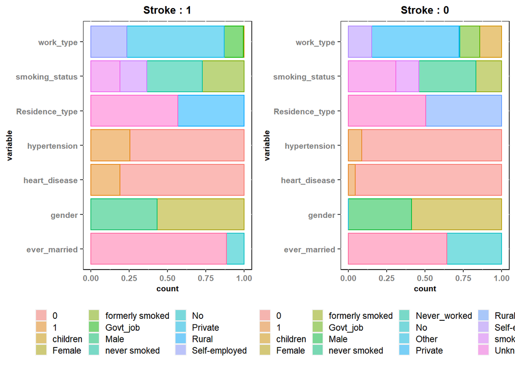

```r
df1<-subset(df_fac, df_fac$stroke==1) ## df에서 stroke 1인 행만 고르기

stroke_plot_1 = ggplot(df1, aes(x=variable, fill=value, color=value))+
  geom_bar(position = 'fill', alpha=0.5)+
  coord_flip()+
  theme(panel.background = element_rect(fill = 'white', color = 'black', linetype = 'solid'),
        axis.title.x = element_text(face = 'bold', size = 8),
        axis.title.y = element_text(face = 'bold', size = 8),
        plot.title = element_text(face = 'bold', size = 10, hjust = 0.5),
        axis.text.x = element_text(face = 'bold', size = 8, colour = 'grey50'),
        axis.text.y = element_text(face = 'bold', size = 8, colour = 'grey50'),
        legend.position = 'bottom',
        legend.title = element_blank(),
        legend.key.size = unit(4,'mm'))+
  labs(x='variable', title = 'Stroke : 1')+
  guides(color=FALSE)


df2<-subset(df_fac, df_fac$stroke==0) ## df에서 stroke 0인 행만 고르기

stroke_plot_2 = ggplot(df2, aes(x=variable, fill=value, color=value))+
  geom_bar(position = 'fill', alpha=0.5)+
  coord_flip()+
  theme(panel.background = element_rect(fill = 'white', color = 'black', linetype = 'solid'),
        axis.title.x = element_text(face = 'bold', size = 8),
        axis.title.y = element_text(face = 'bold', size = 8),
        plot.title = element_text(face = 'bold', size = 10, hjust = 0.5),
        axis.text.x = element_text(face = 'bold', size = 8, colour = 'grey50'),
        axis.text.y = element_text(face = 'bold', size = 8, colour = 'grey50'),
        legend.position = 'bottom',
        legend.title = element_blank(),
        legend.key.size = unit(4,'mm'))+
  labs(x='variable', title = 'Stroke : 0')+
  guides(color=FALSE)

gridExtra::grid.arrange(stroke_plot_1, stroke_plot_2, ncol=2)
```

### 문제 5.

```r
data.1<-subset(data, data$stroke==1)
numeric.1<-data.1 %>% select(c(where(is.numeric),-stroke))
df.num.1<-numeric.1 %>% gather(key = 'variable', value = 'values') %>% group_by(variable, values) %>% summarise(count=n()) %>% as.data.frame()
```

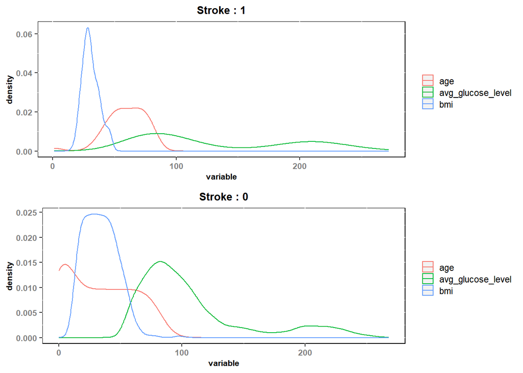

```r
stroke_plot_3 = ggplot(df.num.1, aes(x = values, color=variable))+
  geom_density(fill = NA)+
  geom_line(stat = 'density')+
  theme(panel.background = element_rect(fill = 'white', color = 'black', linetype = 'solid'),
        axis.title.x = element_text(face = 'bold', size = 8),
        axis.title.y = element_text(face = 'bold', size = 8),
        plot.title = element_text(face = 'bold', size = 10, hjust = 0.5),
        axis.text.x = element_text(face = 'bold', size = 8, colour = 'grey50'),
        axis.text.y = element_text(face = 'bold', size = 8, colour = 'grey50'),
        legend.position = 'right',
        legend.title = element_blank(),
        legend.key.size = unit(4,'mm'))+
  labs(x='variable', title = 'Stroke : 1')


data.2<-subset(data, data$stroke==0)
numeric.2<-data.2 %>% select(c(where(is.numeric),-stroke))
df.num.2<-numeric.2 %>% gather(key = 'variable', value = 'values') %>% group_by(variable, values) %>% summarise(count=n()) %>% as.data.frame()
stroke_plot_4 = ggplot(df.num.2, aes(x = values, color=variable))+
  geom_density(fill = NA)+
  geom_line(stat = 'density')+
  theme(panel.background = element_rect(fill = 'white', color = 'black', linetype = 'solid'),
        axis.title.x = element_text(face = 'bold', size = 8),
        axis.title.y = element_text(face = 'bold', size = 8),
        plot.title = element_text(face = 'bold', size = 10, hjust = 0.5),
        axis.text.x = element_text(face = 'bold', size = 8, colour = 'grey50'),
        axis.text.y = element_text(face = 'bold', size = 8, colour = 'grey50'),
        legend.position = 'right',
        legend.title = element_blank(),
        legend.key.size = unit(4,'mm'))+
  labs(x='variable', title = 'Stroke : 0')

gridExtra::grid.arrange(stroke_plot_3, stroke_plot_4)
```

### 문제 6.

```r
cate_var<-c('gender', 'hypertension', 'heart_disease', 'ever_married', 'work_type','Residence_type','smoking_status')
chi<-c(rep(NA,7))
chi_check<-data.frame(cate_var, chi)

for (i in 1:length(chi_check$cate_var)) {
  chi_score = chisq.test(data$stroke, data[,cate_var[i]])
  chi_result <- ifelse(chi_score$p.value < 0.05, 'denied', 'accept')
  chi_check[i,'chi'] = chi_result
}
chi_check
```

```
##         cate_var    chi
## 1         gender accept
## 2   hypertension denied
## 3  heart_disease denied
## 4   ever_married denied
## 5      work_type denied
## 6 Residence_type accept
## 7 smoking_status denied
```

### 문제 7.

gender & Residence_type; 기각 못해->제거

```r
data %<>%select(-c('gender', 'Residence_type'))
data %>% colnames()
```

```
## [1] "age"               "hypertension"      "heart_disease"
## [4] "ever_married"      "work_type"         "avg_glucose_level"
## [7] "bmi"               "smoking_status"    "stroke"
```

## [Test data(test.csv) 전처리]

### 문제 8.

```r
test %>% str()
```

```
## 'data.frame':    1023 obs. of  12 variables:
##  $ id               : int  56669 58202 13861 38047 69160 47306 47167 38829 58631 72366 ...
##  $ gender           : chr  "Male" "Female" "Female" "Female" ...
##  $ age              : num  81 50 52 65 59 58 77 82 73 76 ...
##  $ hypertension     : int  0 1 1 0 0 0 1 0 1 0 ...
##  $ heart_disease    : int  0 0 0 0 0 0 0 0 0 0 ...
##  $ ever_married     : chr  "Yes" "Yes" "Yes" "Yes" ...
##  $ work_type        : chr  "Private" "Self-employed" "Self-employed" "Private" ...
##  $ Residence_type   : chr  "Urban" "Rural" "Urban" "Rural" ...
##  $ avg_glucose_level: num  186 167 233 101 212 ...
##  $ bmi              : chr  "29" "30.9" "48.9" "28.2" ...
##  $ smoking_status   : chr  "formerly smoked" "never smoked" "never smoked" "formerly smoked" ...
##  $ stroke           : int  1 1 1 1 1 1 1 1 1 1 ...
```

```r
test$bmi<-as.numeric(test$bmi)
colSums(is.na(test))
```

```
##                id            gender               age      hypertension
##                 0                 0                 0                 0
##     heart_disease      ever_married         work_type    Residence_type
##                 0                 0                 0                 0
## avg_glucose_level               bmi    smoking_status            stroke
##                 0                36                 0                 0
```

```r
for (i in 1:ncol(test)) {
  test[,i][is.na(test[,i])]<-mean(test[,i], na.rm = TRUE)
}
colSums(is.na(test))
```

```
##                id            gender               age      hypertension
##                 0                 0                 0                 0
##     heart_disease      ever_married         work_type    Residence_type
##                 0                 0                 0                 0
## avg_glucose_level               bmi    smoking_status            stroke
##                 0                 0                 0                 0
```

```r
test[c(2,6:8,11)] <- lapply(test[c(2,6:8,11)], as.factor)

test[c(4:5,12)] <- lapply(test[c(4:5,12)], as.factor)
str(test)
```

```
## 'data.frame':    1023 obs. of  12 variables:
##  $ id               : num  56669 58202 13861 38047 69160 ...
##  $ gender           : Factor w/ 2 levels "Female","Male": 2 1 1 1 2 2 1 1 2 2 ...
##  $ age              : num  81 50 52 65 59 58 77 82 73 76 ...
##  $ hypertension     : Factor w/ 2 levels "0","1": 1 2 2 1 1 1 2 1 2 1 ...
##  $ heart_disease    : Factor w/ 2 levels "0","1": 1 1 1 1 1 1 1 1 1 1 ...
##  $ ever_married     : Factor w/ 2 levels "No","Yes": 2 2 2 2 2 1 2 2 2 2 ...
##  $ work_type        : Factor w/ 5 levels "children","Govt_job",..: 4 5 5 4 4 4 5 4 5 4 ...
##  $ Residence_type   : Factor w/ 2 levels "Rural","Urban": 2 1 2 1 1 1 2 1 2 2 ...
##  $ avg_glucose_level: num  186 167 233 101 212 ...
##  $ bmi              : num  29 30.9 48.9 28.2 29.2 ...
##  $ smoking_status   : Factor w/ 4 levels "formerly smoked",..: 1 2 2 1 1 4 2 2 2 4 ...
##  $ stroke           : Factor w/ 2 levels "0","1": 2 2 2 2 2 2 2 2 2 2 ...
```

```r
test %<>%select(-c('id','gender', 'Residence_type'))
test %>% colnames()
```

```
## [1] "age"               "hypertension"      "heart_disease"
## [4] "ever_married"      "work_type"         "avg_glucose_level"
## [7] "bmi"               "smoking_status"    "stroke"
```

# Chapter 2. Catboost

### 문제 0. Catboost 특성 & 파라미터 설명

```r
library(catboost)
library(caret)
library(MLmetrics)
```

Catboost는 XGBoost와 더불어 level-wise로 트리를 만들어 간다. 또한 일괄적으로 모든 훈련 데이터를 대상으로 잔차계산을 하는 기존의 부스팅 모델과는 달리, Catboost는 일부만 가지고 잔타계산을 한뒤, 이로 모델을 만들고, 이 모델로 예측한 값을 데이터의 잔차로 활용하는 Ordered Boosting방식을 따른다. 오버피팅 방지를 위해 데이터를 셔플링해서 뽑아낸다. Ordered Target Encoding방식으로 범주형 변수를 인코딩 한다. 또한 inforation gain이 동일한 두 feature를 하나의 feature로 묶기에 feature selection에 도움이 된다. 가장 큰 특징?으로는 기본 파라미터가 기본적으로 최적화가 잘 되어있어 파라미터 튜닝에 크게 신경쓰지 않아도 된다는 점인데(내부적 알고리즘으로 트리의 다향성과 오버피팅 문제를 해결함) 굳이 한다면 learning_rate, random_strength, L2_regulariser와 같은 파라미터다. has_time=True로 하면 시간이 지남에 따라 데이터가 변경되는 경우에 적용할 수 있다. sample_weight를 통해 특정 데이터 포인트에 가중치 부여 가능 task_type = GPU로 설정하면 GPU에서 CatBoost 훈련이 가능해져 대규모 데이터 작업이 가능해 진다.

### 문제 1. 데이터프레임 만들기

```r
logloss_cb <- expand.grid(depth = c(4, 6, 8),
                          iterations=c(100,200), logloss = c(NA))
logloss_cb
```

```
##   depth iterations logloss
## 1     4        100      NA
## 2     6        100      NA
## 3     8        100      NA
## 4     4        200      NA
## 5     6        200      NA
## 6     8        200      NA
```

### 문제 2. grid search 5-fold CV

```r
data$stroke<-data$stroke %>% as.integer()
test$stroke<-test$stroke %>% as.integer()
data.pool <- catboost.load_pool(data = select(data, - stroke),
                                label = data$stroke)
test.pool <- catboost.load_pool(data = select(test, -stroke),
                                label = test$stroke)
cv <- caret::createFolds(data$stroke, k = 5)


for(j in 1 : nrow(logloss_cb)){
  logloss_result = c()
  for(i in 1:5){
    idx = cv[[i]]
    train_set = data[-idx,]
    test_set = data[idx,]

    cv_train_pool=catboost.load_pool(data=select(train_set,-stroke),
                                     label = train_set$stroke)

    cv_test_pool = catboost.load_pool(data = select(test_set, -stroke),
                                      label = test_set$stroke)


    cb_model = catboost.train(learn_pool = cv_train_pool,
                              params = as.list(logloss_cb[j,-3],
                                               random_seed = 1234))

    predict = catboost.predict(cb_model, cv_test_pool)

    logloss = LogLoss(predict, test_set$stroke)

    logloss_result = c(logloss_result, logloss)
  }
  cv_mean_logloss = mean(logloss_result)
  logloss_cb[j,3]=cv_mean_logloss
}
```

[output not shown]

[output cut: 4515 more lines]

```r
logloss_cb %>% print()
```

```
##   depth iterations   logloss
## 1     4        100 -1.569491
## 2     6        100 -1.504164
## 3     8        100 -1.419864
## 4     4        200 -1.574899
## 5     6        200 -1.497776
## 6     8        200 -1.492539
```

### 문제 3. 가장 낮은 logloss

```r
logloss_cb[which.min(logloss_cb$logloss),]
```

```
##   depth iterations   logloss
## 4     4        200 -1.574899
```

### 문제 4. 가장 낮은 logloss로 학습해 test에 대한 logloss구하기

```r
data.pool <- catboost.load_pool(data = select(data, - stroke),
                                label = data$stroke)
test[c(3:4)] <- lapply(test[c(3:4)], as.factor)

test.pool <- catboost.load_pool(data = select(test, -stroke),
                                label = test$stroke)

cb_model = catboost.train(learn_pool = data.pool,
                          params = as.list(logloss_cb[4,-3],
                                           random_seed = 1234))
```

[output not shown]

[output cut: 186 more lines]

```r
pred.cb = catboost.predict(cb_model, test.pool)

LogLoss(pred.cb, test$stroke)
```

```
## [1] -1.533163
```

# Chapter 3. K-means Clustering

```r
library(factoextra)
library(cluster)
```

### 문제 1. 수치형 변수 scale 정규화

```r
num.age <- scale(data$age)
num.avg_glucose_level <- scale(data$avg_glucose_level)
num.bmi <- scale(data$bmi)
numeric.data<-data.frame(num.age, num.avg_glucose_level, num.bmi)
```

### 문제 2. fiviz_nbclust로 시각화 & 적절한 K?

##### Elbow method

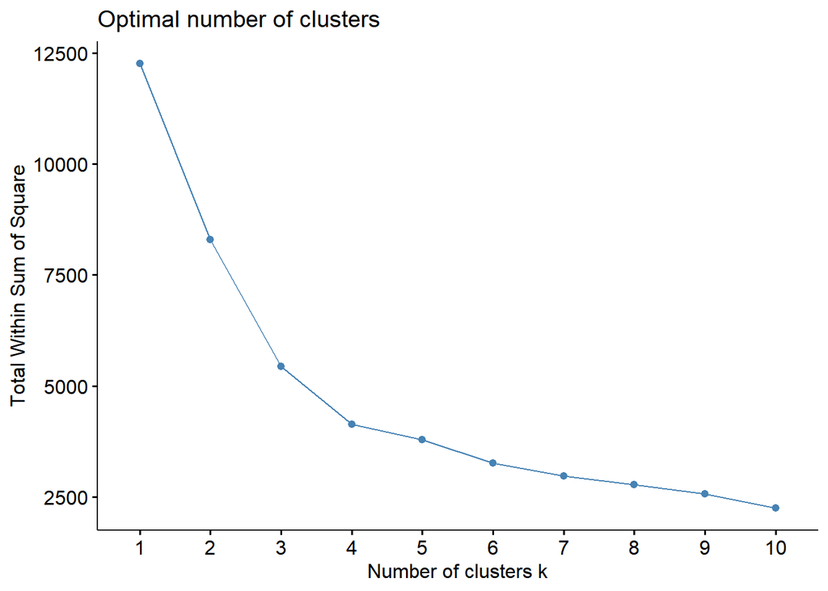

```r
fviz_nbclust(numeric.data, kmeans, method = "wss")
```

k=4; 급격하게 줄어드는 양상을 띔

##### Silhouette Method

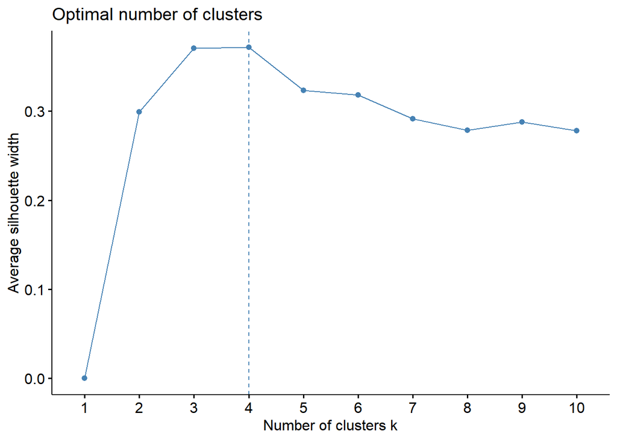

```r
fviz_nbclust(numeric.data, kmeans, method = 'silhouette')
```

k=4; 실루엣계수가 가장 높음

### 문제 3. k-means 클러스터링 & 시각화

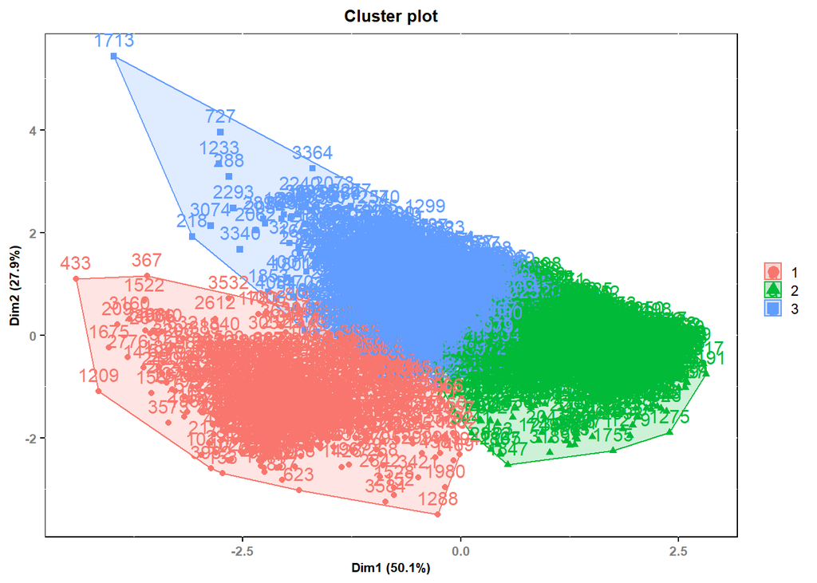

```r
set.seed(1234)
data.cluster<-kmeans(numeric.data, 3, nstart = 1, iter.max = 30)
cluster_plot = fviz_cluster(data.cluster, data = numeric.data, stand=F, outlier.shape = NA)+
  theme(panel.background = element_rect(fill = 'white', color = 'black', linetype = 'solid'),
        axis.title.x = element_text(face = 'bold', size = 8),
        axis.title.y = element_text(face = 'bold', size = 8),
        plot.title = element_text(face = 'bold', size = 10, hjust = 0.5),
        axis.text.x = element_text(face = 'bold', size = 8, colour = 'grey50'),
        axis.text.y = element_text(face = 'bold', size = 8, colour = 'grey50'),
        legend.position = 'right',
        legend.title = element_blank(),
        legend.key.size = unit(4,'mm'))
cluster_plot
```

### 문제 4. age, avg_glucose_level, bmi에 대해 boxplot시각화 & 해석

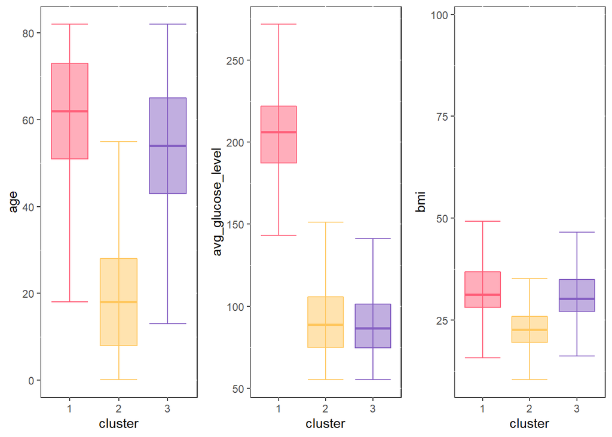

```r
## 숫자형 변수 data에서 따로 꺼낸 다음, k-means에서 나온 클러스터들은 그 데이터 프레임에 붙여서 새로운 데이터 프레임 만들고 다시 select로 age/cluster, avg/cluster, bmis/cluster 이렇게 총 3개 데이터 프레임으로 쪼개 서 각각 박스플랏 만들기
cluster.data = data %>% select(where(is.numeric)) %>% mutate(cluster= data.cluster$cluster)

age.cluster = cluster.data %>% ggplot(aes(x=factor(cluster),y=age)) + geom_boxplot(outlier.shape = NA, alpha=0.5,fill=c("#ff5e78", "#ffc75f", "#845ec2"),color=c("#ff5e78", "#ffc75f", "#845ec2")) + stat_boxplot(geom='errorbar',color=c("#ff5e78", "#ffc75f", "#845ec2")) + labs(x='cluster') + theme(panel.background = element_rect(fill = "white",color = "black"))

glucose.cluster = cluster.data %>% ggplot(aes(x=factor(cluster),y=avg_glucose_level)) + geom_boxplot(outlier.shape = NA, alpha=0.5,fill=c("#ff5e78", "#ffc75f", "#845ec2"),color=c("#ff5e78", "#ffc75f", "#845ec2")) + stat_boxplot(geom='errorbar',color=c("#ff5e78", "#ffc75f", "#845ec2")) + labs(x='cluster') + theme(panel.background = element_rect(fill = "white",color = "black"))

bmi.cluster = cluster.data %>% ggplot(aes(x=factor(cluster),y=bmi)) + geom_boxplot(outlier.shape = NA, alpha=0.5,fill=c("#ff5e78", "#ffc75f", "#845ec2"),color=c("#ff5e78", "#ffc75f", "#845ec2")) + stat_boxplot(geom='errorbar',color=c("#ff5e78", "#ffc75f", "#845ec2")) + labs(x='cluster') + theme(panel.background = element_rect(fill = "white",color = "black"))

grid.arrange(age.cluster, glucose.cluster, bmi.cluster, ncol = 3)
```